# Assignment 2: Temperature and Precipitation Patterns

Laura Tomkins

March 2018

## Introduction

It is fairly well accepted among the scientific community that the global temperatures around the globe are increasing. Temperature records have shown increasing temperatures over the past century compared to pre-industrial records. This trend has been documented as early as the 1960s (Mitchell 1961). This is increase is thought to be largely anthropogenic, due to the increase in greenhouse gases from burning fossil fuels. This report will attempt to use some temperature records available to show these changing temperatures. Along with global warming, increasing the concentration of CO2 also has implications for other parts of our atmosphere. Climate change will likely change our weather patterns and thus our precipitation patterns (Stocker et al. 2013). Precipitation data is also provided in this report which will also be analyzed for evidence of climate change.

## Methods

#### Research Questions

For this assignement we will attempt to answer the following 3 questions provided from the assignment instructions:  
1. Can we see climate warming for ourselves by analyzing these data?  
2. In what parts of the country are temperatures getting warmer? Are there any parts that actually got colder over 1950-2010?  
3. Can we say, based on these data, What change has occurred in precipitation over the period?

To analyze trends in the data, a regression analysis will be used to look at any general trends in the averages of the data. To analyze spatial trends in the data, plots of regression slopes for each location will be plotted to see areas which increase and areas which decrease.

## Data

The data used in this analysis is annual temperature and precipitation data from various locations over the continental U.S. Data was either provided from the instructor or downloaded from online. It should be noted that this data has been quality controlled to remove stations which have less than 40 years of data. The temperature data consists of observations from 6328 stations and the precipitation data consists of observations from 491 stations. The termperature data is fairly well distributed over the entire continental U.S. however, the precipitation data only covers 3 states which may result in some complications.

## Results

### Temperature

The following is an analysis ofthe temperature data.

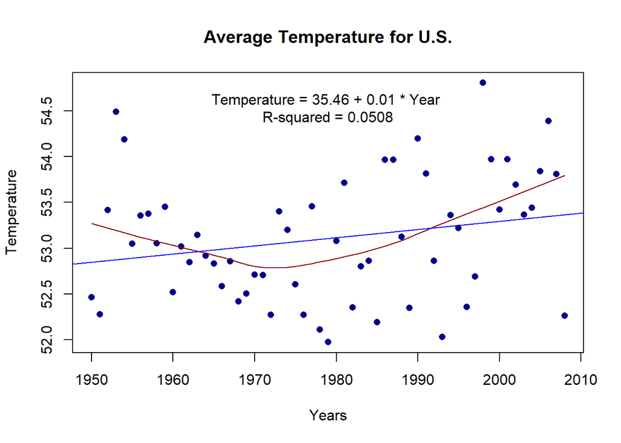

Figure 1. Annual average annual temperature for U.S.

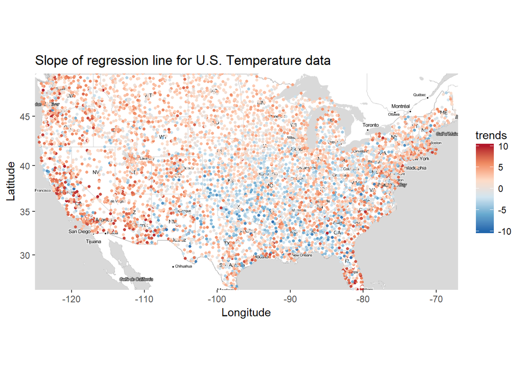

Figure 2. Spatial trends for average annual temperature for U.S.

Figure 1 shows a plot of the average annual temperature for the United States. Years are shown on the x axis and average temperature on the y axis. The blue line represents the regression line with the equation and r-squared value shown at the top and the red line represents the locally weighted scatterplot smoothing (LOWESS) line. We can see that the regression line has a general positive trend, however the r-squared value is very small (r-squared = 0.0508) and the data do not fit this line particularly well. The LOWESS line shows a trend in the data which is more curved as there appeared to be some cooling in the U.S. during the 1970s followed by warming into the 1980s through the 2000s. Because this averages temperatures for all the locations it does not account of areas where there may be cooling and areas where there may be warming, so this is not necessarily the best way to see this. We are also slightly limited because if we want to study the warming trend we should really look at temperature before the industrial revolution to get a better sense of the warming.

To observe a spatial trend of the data the slope of the regression line for each station is plotted in figure 2. Here we can see a mixture of cooling (blue dots) and warming(red dots). It appears as though there is a concentration of blue dots around the southern plains/deep south region of the U.S. Most other locations appear to show warming trends.

### Precipitation

The next part of this analysis will focus on the change in precipitation patterns. As is stated previously, we only have precipitation data for Ohio, Tennessee, and Alabama. This present issues for making conclusions about patterns over the whole US since we don’t have data for most of our area. We can only make conclusions about those states where we have data.

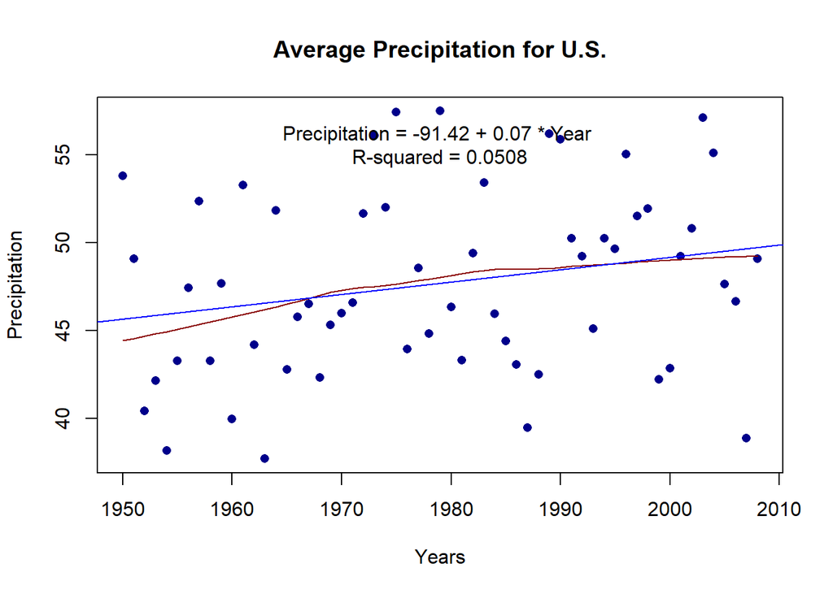

Figure 3. Annual average annual precipitation for U.S.

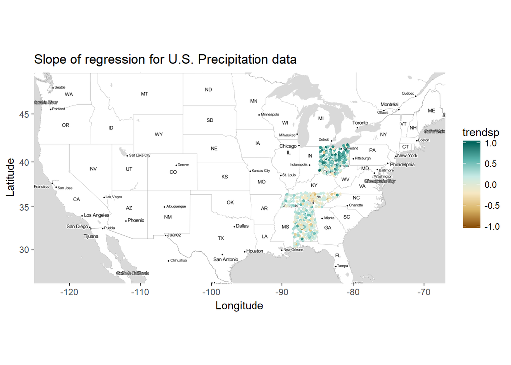

Figure 4. Spatial trends for average annual precipitation for U.S.

Figure 4 shows the regression slope for the individual locations. Here we find that most locations show an increase in precipitation, however there are a few locations which show a decrease in precipitation.

## References

Mitchell, J Murray. 1961. “Recent Secular Changes of Global Temperature.” *Annals of the New York Academy of Sciences* 95 (1). Wiley Online Library: 235–50.

Stocker, T.F., D. Qin, G.-K. Plattner, L.V. Alexander, S.K. Allen, N.L. Bindoff, F.-M. Bréon, et al. 2013. “Technical Summary.” Book Section. In *Climate Change 2013: The Physical Science Basis. Contribution of Working Group I to the Fifth Assessment Report of the Intergovernmental Panel on Climate Change*, edited by T.F. Stocker, D. Qin, G.-K. Plattner, M. Tignor, S.K. Allen, J. Boschung, A. Nauels, Y. Xia, V. Bex, and P.M. Midgley, 33–115. Cambridge, United Kingdom; New York, NY, USA: Cambridge University Press. doi:10.1017/CBO9781107415324.005.